# HW4

Wangqian Miao

### Problem 1

**(a)**

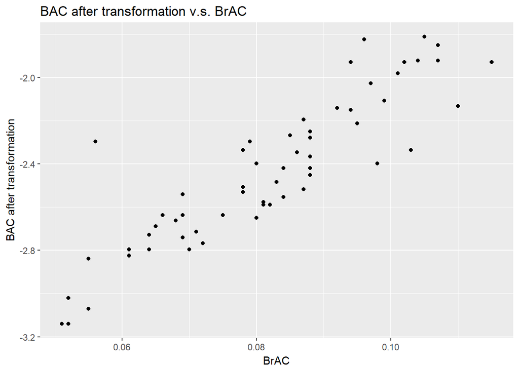

The method I use is loglikelihood. The value of $\lambda$ is -0.3210369.

**(b)**

```
##
## Results of Hypothesis Test
## --------------------------
##
## Alternative Hypothesis:
##
## Test Name:                       Fligner-Killeen test of homogeneity of variances
##
## Data:                            t.data$ei and t.data$Group
##
## Test Statistic:                  Fligner-Killeen:med chi-squared = 1.627073
##
## Test Statistic Parameter:        df = 1
##
## P-value:                         0.2021083
```

I use F-K test to test whether the variance is constant.  
$H_{0}: \sigma^{2}_{lower}=\sigma^{2}_{upper}$. $H_{0}: \sigma^{2}_{lower}\neq\sigma^{2}_{upper}$.

P-value is $0.2021>\alpha=0.05$, we fail to reject $H_{0}$ and the conclusion is that the variance is constant at $95\%$ significance.

**(c)**

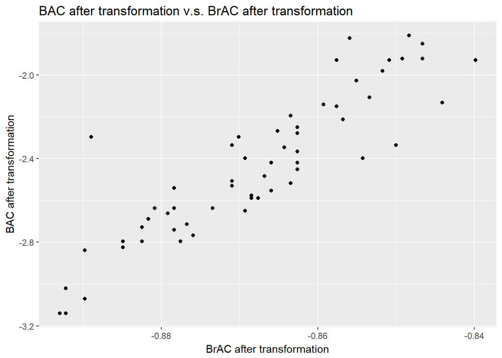

**(d)**

```
##
## Results of Hypothesis Test
## --------------------------
##
## Alternative Hypothesis:
##
## Test Name:                       Shapiro-Wilk normality test
##
## Data:                            ei
##
## Test Statistic:                  W = 0.9388731
##
## P-value:                         0.005282791
```

```
##
## Results of Hypothesis Test
## --------------------------
##
## Alternative Hypothesis:
##
## Test Name:                       Fligner-Killeen test of homogeneity of variances
##
## Data:                            t2.data$ei and t2.data$Group
##
## Test Statistic:                  Fligner-Killeen:med chi-squared = 1.813311
##
## Test Statistic Parameter:        df = 1
##
## P-value:                         0.1781116
```

S-W test:  
$H_{0}$:The data is normally distributed.  
$H_{A}$:The data is not normally distributed.  
P-value is $0.005283<\alpha=0.01$, we will reject $H_{0}$. I conclude that the data is not normally distributed.

F-K test:  
$H_{0}:\sigma^{2}_{lower}=\sigma^{2}_{upper}$  
$H_{A}:\sigma^{2}_{lower}\neq\sigma^{2}_{upper}$  
Conclusion:  
P-value is $0.1781>\alpha=0.05$, we fail to reject $H_{0}$ and conclude that the variance is constant.

**(e)**

I woud suggest transformation only for Y. Accoding to the p-value of F-K test for dataset with transformed BAC is larger than that for dataset with transformed BrAC and BAC.

### Problem 2

**(a)**

```
## (Intercept)         age       aware     genderM
## -1.17715922  0.07278802 -0.09898649  0.43397485
```

```
## (Intercept)     exp.age   exp.aware exp.genderM
##   0.3081529   1.0755025   0.9057549   1.5433801
```

```
##                     5 %        95 %
## (Intercept) -6.12525730  3.73588964
## age          0.02397254  0.12459096
## aware       -0.15801887 -0.04707586
## genderM     -0.41506185  1.31602883
```

```
##                     5 %      95 %
## (Intercept) 0.002186928 41.925307
## exp.age     1.024262188  1.132685
## exp.aware   0.853833667  0.954015
## exp.genderM 0.660299443  3.728585
```

The estimated logistic-regression function : $\ln \frac{\hat{\pi}}{1-\hat{\pi}} = -1.1772 + 0.0728X_{1} -0.099X_{2} + 0.434X_{M}$. ($X_1$=age, $X_2$=aware)

**(b)**

```
##          1
## 0.02487026
```

**(c)**

Because $\beta_{1} = 0.0728$, the probability of a flu shot goes up as your age increases.

**(d)**

When age increases by 1 year, the odds of flu shot will be 1.0755 times that of what it was holding other variables constant.

**(e)**

The $90\%$ C.I. for $\exp{\hat{\beta_1}}$ is [1.0242622, 1.132685]. When age increases by 1 year, we are $90\%$ in confidence that the odds of flu shot will be between 1.0243 times and 1.1327 times as what it was holding other variables constant.

**(f)**

The odds of flu shot for Male is 1.5434 times the odds for Female holding all other variables as constant.

**(g)**

The $90\%$ C.I. for $\exp{\hat{\beta_3}}$ is [0.6602994, 3.7285851]. We are $90\%$ in confidence that the odds of flu shot will be between 0.6603 times and 3.7286 times the odds for Female holding other variables constant.

### Problem 3

**(a)**

There is no meaning for interpreting $\beta_0$. $\exp(\beta_{0})$ represents the odds of a female patient who is 0 year old and has no awareness of health which is meaningless.

**(b)**

The age in the dataset is range from [48,84]. So, it is not appropriate to predict someone aged 12.

**(c)**

```
## Sensitivity Specificity  Error Rate
##      0.0444      0.9630      0.1447
```

**(d)**

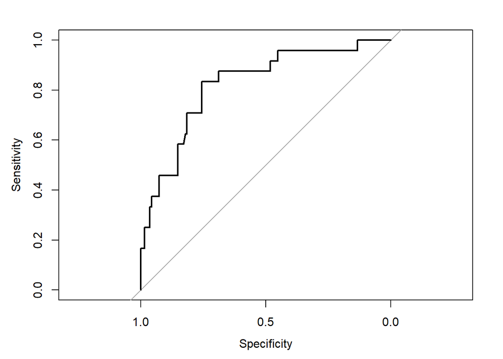

```
## Area under the curve: 0.8224
```

```
## 95% CI: 0.7308-0.9139 (DeLong)
```

AUC is 0.8224. The $95\%$ confident interval for AUC is [0.7308,0.9139]. It does not contain 0.5 which means our model predicts the response variable very well.

### Problem 4

**(a)**

```
## (Intercept)         AGE
##  -5.3094534   0.1109211
```

```
## (Intercept)     exp.AGE
## 0.004944629 1.117306795
```

```
##                    0.5 %    99.5 %
## (Intercept) 0.0001887908 0.0703886
## exp.AGE     1.0557140982 1.1970787
```

The estimated logistic-regression function : $\ln \frac{\hat{\pi}}{1-\hat{\pi}} = -5.3095 + 0.1109X_{1}$.

**(b)**

The estimated probability for a 69 year old person to have CHD is 0.9125.

**(c)**

When the age increases by one year, the odds of CHD tends to be 1.1173 times what is was holding other variables constant.

### Problem 5

**(a)**

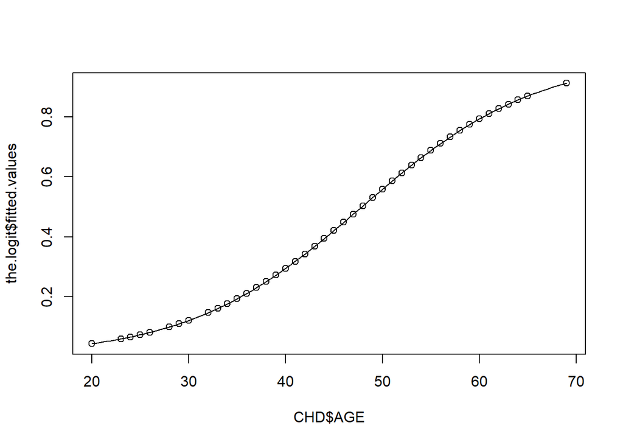

**(b)**

$\exp({\beta_{0}})$ represents the odds of CHD for a 0 year old, so $\exp({\beta_{0})}$ does not have a praticle meaning because nobody can be 0 year old.

**(c)**

I think it makes sense to predict CHD for someone aged 44. Because according to the dataset the age is range from 20 to 69.

**(d)**

```
## Sensitivity Specificity  Error Rate
##      0.5088      0.7895      0.2600
```

**(e)**

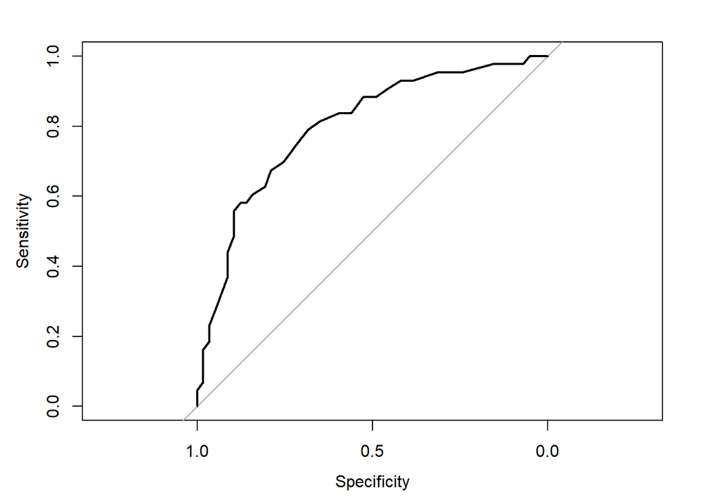

```
## Area under the curve: 0.7999
```

```
## 95% CI: 0.7114-0.8884 (DeLong)
```

AUC is 0.7999. The $95\%$ confident interval for AUC is [0.7114,0.8884]. The C.I. does not contain 0.5 which suggests our model predicts $Y$ well.

### Problem 6

**(a)**

True.  
When $\exp({\beta_{1}})$ contains 1 which means $\beta_{1}$ contains 0. We can conclude $X_{1}$ has no influence on the odds of $Y=1$.

**(b)**

False. $\exp(\beta_1)$ gives us when $X_1$ increases 1 unit, how much odds will be times the old one.

**(c)**

False.  
It just depends on whether it is meaningful to set all $X_i$ equals 0.

**(d)**

True.  
We accept $H_{0}: \beta_{1} = 0$ which means $X_{1}$ does not affect the odds of trait($Y=1$).

### R Appendix

```r
alcohol = read.csv("alcohol.csv")
CHD = read.csv("CHD.csv")
flu = read.csv("flu.csv")
library(ggplot2)
library(pROC)
library(EnvStats)
the.model=lm(BAC~BrAC,data=alcohol)
LY = boxcox(alcohol$BAC, objective.name = "Log-Likelihood", optimize = TRUE)$lambda
YT = (alcohol$BAC^LY - 1)/LY
t.data = data.frame(Y = YT, X = alcohol$BrAC)
qplot(X, Y, data = t.data) + ggtitle("BAC after transformation v.s. BrAC") + xlab("BrAC") + ylab("BAC after transformation")
the.model = lm(Y~X, data = t.data)
Group = rep("Lower", nrow(t.data))
Group[t.data$Y < median(t.data$Y)] = "Upper"
Group = as.factor(Group)
t.data$Group = Group
t.data$ei = the.model$residuals
t.data$yhat = the.model$fitted.values
the.FKtest = fligner.test(t.data$ei, t.data$Group)
the.FKtest
LY = boxcox(alcohol$BAC, objective.name = "Log-Likelihood", optimize = TRUE)$lambda
YT = (alcohol$BAC^LY - 1)/LY
LX = boxcox(alcohol$BrAC, objective.name = "Log-Likelihood", optimize = TRUE)$lambda
XT = (alcohol$BrAC^LX - 1)/LX
t2.data = data.frame(Y = YT, X = XT)
qplot(XT, YT, data = t2.data) + ggtitle("BAC after transformation v.s. BrAC after transformation") + xlab("BrAC after transformation") + ylab("BAC after transformation")
the.model = lm(Y~X, data = t2.data)
ei = the.model$residuals
t2.data$ei = the.model$residuals
t2.data$yhat = the.model$fitted.values
the.SWtest = shapiro.test(ei)
the.SWtest

Group = rep("Lower", nrow(t2.data))
Group[t2.data$Y < median(t2.data$Y)] = "Upper"
Group = as.factor(Group)
t2.data$Group = Group
the.FKtest = fligner.test(t2.data$ei, t2.data$Group)
the.FKtest

the.logit = glm(shot~age + aware + gender, data = flu, family = binomial(link = logit))
the.betas = the.logit$coefficients
the.betas
exp.betas = exp(the.betas)
names(exp.betas) = c("(Intercept)", "exp.age", "exp.aware", "exp.genderM")
exp.betas
alpha = 0.1
the.CI = confint(the.logit, level = 1 - alpha)
the.CI
exp.CI = exp(the.CI)
rownames(exp.CI) = c("(Intercept)", "exp.age", "exp.aware", "exp.genderM")
exp.CI
x.star = data.frame(age = 55, aware = 70, gender = "M")
the.predict = predict(the.logit, x.star, type = "response")
the.predict



max=max(flu$age)
min=min(flu$age)
pi.0 = 0.50
truth = flu$shot
predicted = ifelse(fitted(the.logit)>pi.0, 1, 0)
the.table = table(truth, predicted)
sens = sum(predicted ==1 & truth == 1)/sum(truth == 0)
spec = sum(predicted ==0 & truth == 0)/sum(truth == 0)
error = sum(predicted != truth)/length(predicted)
results = c(sens, spec, error)
names(results) = c("Sensitivity", "Specificity", "Error Rate")
round(results, 4)
the.auc = auc(flu$shot, fitted(the.logit), plot = TRUE)
the.auc
auc.CI = ci(the.auc, level = 1-0.05)
auc.CI
the.logit = glm(CHD~AGE, data = CHD, family = binomial(link = logit))
the.betas = the.logit$coefficients
the.betas
exp.betas = exp(the.betas)
names(exp.betas) = c("(Intercept)", "exp.AGE")
alpha = 0.01
the.CI = confint(the.logit, level = 1 - alpha)
exp.CI = exp(the.CI)
rownames(exp.CI) = c("(Intercept)", "exp.AGE")
exp.betas
exp.CI
x.star = data.frame(AGE = 69)
the.predict = predict(the.logit, x.star, type = "response")


the.logit = glm(CHD~AGE, data = CHD, family = binomial(link = logit))
plot(CHD$AGE, the.logit$fitted.values)
curve(predict(the.logit, data.frame(AGE=x), type = "response"), add = TRUE)

pi.0 = 0.50
truth = CHD$CHD
predicted = ifelse(fitted(the.logit)>pi.0, 1, 0)
the.table = table(truth, predicted)
sens = sum(predicted ==1 & truth == 1)/sum(truth == 0)
spec = sum(predicted ==0 & truth == 0)/sum(truth == 0)
error = sum(predicted != truth)/length(predicted)
results = c(sens, spec, error)
names(results) = c("Sensitivity", "Specificity", "Error Rate")
round(results, 4)
the.auc = auc(CHD$CHD, fitted(the.logit), plot = TRUE)
the.auc
auc.CI = ci(the.auc, level = 1-0.05)
auc.CI
```